# Xuanyou_0513868

# First step complete

The initial model (`3 × [Conv+Pool] + Flatten + Dense`) achieved a validation accuracy (**val_acc**) of approximately **60.3%** with a loss (**val_loss**) of **1.57** after 40 epochs. This served as the baseline for subsequent optimizations.

# Second step

In this step some of the parameters and hyperparameters are tried to find the best model architechtrue and training process

- For Modell-Architektur
  - filter number
  - kernel size
  - dense units
  - dropout percentage
- For Traning-Prozess
  - weight decay
  - defferent optimizer
  - lr
  - batch size

```python
# imports
import keras_tuner as kt
from keras.callbacks import EarlyStopping, TensorBoard
from tensorboard.plugins.hparams import api as hp  # TensorBoard HParams
```

```python
data_augmentation = keras.Sequential([
    layers.RandomFlip("horizontal"),
    layers.RandomRotation(0.15),
    layers.RandomZoom(0.1),
])
```

```python
import keras_tuner as kt
from tensorflow import keras
from keras import layers, models, regularizers
import pandas as pd
import numpy as np

# ───────────────── build function ──────────────────
def build_full(hp):
    """fix 3xConv+Pool architekture do hp search for filter number / kernel_size /
       Dense units / Dropout / weight-decay / optimizer etc.
    """
    img_height, img_width = 224, 224

    # ── layer hyperparameter ──────────────────────────────
    f0 = hp.Choice("f0", [32, 64, 128])
    f1 = hp.Choice("f1", [64, 128, 256])
    f2 = hp.Choice("f2", [128, 256])

    k  = hp.Choice("kernel_size", [3, 5, 7])
    dense_units = hp.Choice("dense_units", [64, 128, 256])
    dense_dp    = hp.Float("dense_dp", 0.2, 0.5, step=0.1)

    # weight-decay regularization
    wd = hp.Float("weight_decay",
                  min_value=1e-6, max_value=1e-4, sampling="log")
    l2_reg = regularizers.l2(wd)

    # ── the model ───────────────────────────────
    model = models.Sequential([
        layers.Rescaling(1./255, input_shape=(img_height, img_width, 3)),

        layers.Conv2D(f0,  k, padding="same", activation="relu",
                      kernel_regularizer=l2_reg),
        layers.MaxPooling2D(),

        layers.Conv2D(f1,  k, padding="same", activation="relu",
                      kernel_regularizer=l2_reg),
        layers.MaxPooling2D(),

        layers.Conv2D(f2,  k, padding="same", activation="relu",
                      kernel_regularizer=l2_reg),
        layers.MaxPooling2D(),

        layers.Flatten(),
        layers.Dense(dense_units, activation="relu", kernel_regularizer=l2_reg),
        layers.Dropout(dense_dp),
        layers.Dense(num_classes, activation="softmax")
    ])

    # ── train the optimizer ────────────────────────────
    opt_name = hp.Choice("optimizer", ["adam", "rmsprop", "sgd"])
    lr       = hp.Choice("lr", [1e-3, 5e-4, 1e-4])
    if opt_name == "adam":
        optimizer = keras.optimizers.Adam(lr)
    elif opt_name == "rmsprop":
        optimizer = keras.optimizers.RMSprop(lr)
    else:
        optimizer = keras.optimizers.SGD(lr, momentum=0.9, nesterov=True)

    model.compile(optimizer=optimizer,
                  loss="sparse_categorical_crossentropy",
                  metrics=["accuracy"])
    return model
# ────────────────────────────────────────────────

# ---------- use batch_size / plateau as hp ----------
class FullTuner(kt.tuners.BayesianOptimization):
    def run_trial(self, trial, *fit_args, **fit_kwargs):
        hp = trial.hyperparameters
        # batch size
        fit_kwargs["batch_size"] = hp.Choice("batch_size", [16, 32, 64])

        # early stopping & Plateau
        callbacks = [
            keras.callbacks.EarlyStopping(
                monitor="val_accuracy",
                mode="max",
                patience=10,
                min_delta=0.01,
                restore_best_weights=True)
        ]
        if hp.Boolean("use_plateau"):
            callbacks.append(
                keras.callbacks.ReduceLROnPlateau(
                    monitor="val_loss", factor=0.5, patience=3)
            )
        fit_kwargs["callbacks"] = callbacks

        # super() return history.history（dict），which satisfy Keras-Tuner requirements
        return super().run_trial(trial, *fit_args, **fit_kwargs)

# ---------- start to search ----------
tuner = FullTuner(
    build_full,
    objective="val_accuracy",
    max_trials=40,
    max_consecutive_failed_trials=10,
    directory="tune_all",
    project_name="cnn_full",
    overwrite=True,
)

tuner.search(
    train_ds,
    validation_data=val_ds,
    epochs=40,
)

# ---------- get the best model ----------
best_hp     = tuner.get_best_hyperparameters(1)[0]
best_model  = tuner.get_best_models(1)[0]      # get the best model with trained weights
print("★ Best HPs:", best_hp.values)

val_loss, val_acc = best_model.evaluate(val_ds, verbose=0)
print(f"★ Best model  val_acc={val_acc:.3f}  val_loss={val_loss:.3f}")

# ----------  trial → CSV ----------
def safe_last(trial, name):
    return trial.metrics.get_last_value(name) if trial.metrics.exists(name) else np.nan

records = [{
        "trial_id": t.trial_id, **t.hyperparameters.values,
        "status":    t.status,
        "best_epoch": t.best_step,
        "train_acc": safe_last(t, "accuracy"),
        "val_acc":   safe_last(t, "val_accuracy"),
    } for t in tuner.oracle.trials.values()]

pd.DataFrame(records).to_csv("tuner_results.csv", index=False)
print("CSV saved ➜ tuner_results.csv")
```

```
Trial 40 Complete [00h 00m 21s]
val_accuracy: 0.6121794581413269

Best val_accuracy So Far: 0.6570512652397156
Total elapsed time: 00h 28m 32s
```

```
★ Best HPs: {'f0': 128, 'f1': 256, 'f2': 256, 'kernel_size': 7, 'dense_units': 128, 'dense_dp': 0.30000000000000004, 'weight_decay': 4.726311111933952e-05, 'optimizer': 'adam', 'lr': 0.0001, 'batch_size': 16, 'use_plateau': True}
★ Best model  val_acc=0.657  val_loss=1.902
CSV saved ➜ tuner_results.csv
```

**Architecture and Training Optimization:**

Durch Optimierung der Architektur- und Trainingsparameter (Anzahl der Filter, Kernelgröße, Dropout-Rate, Gewicht-Regularisierung, Lernrate, Batch-Größe und Lernraten-Scheduler) wurde ein deutlicher Fortschritt erzielt. Die besten gefundenen Hyperparameter (`f0=128, f1=256, f2=256, Kernelgröße=7, Dense=128, Dropout=0,3, Gewicht-Regularisierung≈4,73e-5, Adam-Optimizer mit LR=1e-4 und Batchgröße=16`) führten zu einer signifikanten Steigerung der Validierungsgenauigkeit auf etwa **65,7 %** bei einem Verlust von **1,90**. Die größere Kernelgröße (7) und eine stärkere Modellkapazität trugen dabei entscheidend zur Verbesserung bei.

# Step 2.2 Data Augumentation

Because of the risk of exploding video memory, I separated this out and trained it on the optimal model some methods are used here

- flip(horizontal flip)
- rot RandomRotation
- zoom RandomZoom

```python
# ───────────── fix the best parameters from last search ──────────────
BEST = {
    "f0": 128, "f1": 256, "f2": 256,     # three Conv blocks
    "k" : 7,                             # kernel_size
    "dense": 128, "dense_dp": 0.3,
    "wd": 4.726311111933952e-05,         # weight-decay
    "lr": 1e-4, "batch_size": 16,
    "use_plateau": True                  # use ReduceLROnPlateau callback
}
l2_reg = regularizers.l2(BEST["wd"])

# ───────────── search for data augumentation HyperModel ─────────────
def build_aug_model(hp):
    # the data augmentation search space
    rot  = hp.Float("rot",  0.0, 0.25, step=0.05)   # 0 → 0.25 (≈ ±45°)
    zoom = hp.Float("zoom", 0.0, 0.25, step=0.05)
    flip = hp.Boolean("flip")

    aug = keras.Sequential([
        layers.Rescaling(1./255, input_shape=(224, 224, 3)),
        layers.RandomFlip("horizontal")   if flip  else layers.Lambda(lambda x:x),
        layers.RandomRotation(rot)        if rot>0 else layers.Lambda(lambda x:x),
        layers.RandomZoom(zoom)           if zoom>0 else layers.Lambda(lambda x:x),
    ], name="augmentation")

    # fix the BEST parameters of model architecture and training
    m = models.Sequential([
        aug,
        layers.Conv2D(BEST["f0"], BEST["k"], padding="same", activation="relu", kernel_regularizer=l2_reg),
        layers.MaxPooling2D(),
        layers.Conv2D(BEST["f1"], BEST["k"], padding="same", activation="relu", kernel_regularizer=l2_reg),
        layers.MaxPooling2D(),
        layers.Conv2D(BEST["f2"], BEST["k"], padding="same", activation="relu", kernel_regularizer=l2_reg),
        layers.MaxPooling2D(),
        layers.Flatten(),
        layers.Dense(BEST["dense"], activation="relu", kernel_regularizer=l2_reg),
        layers.Dropout(BEST["dense_dp"]),
        layers.Dense(num_classes, activation="softmax")
    ])

    opt = keras.optimizers.Adam(learning_rate=BEST["lr"])
    m.compile(opt, loss="sparse_categorical_crossentropy", metrics=["accuracy"])
    return m


# ───────────── Tuner search rot/zoom/flip ─────────────
tuner = kt.BayesianOptimization(
    build_aug_model,
    objective="val_accuracy",
    max_trials=15,
    directory="aug_search",
    project_name="cnn_best_aug",
    overwrite=True
)

# callback（same as BEST model）
callbacks = [
    keras.callbacks.EarlyStopping(monitor="val_accuracy", mode="max",
                                  patience=8, min_delta=0.01,
                                  restore_best_weights=True)
]
if BEST["use_plateau"]:
    callbacks.append(
        keras.callbacks.ReduceLROnPlateau(monitor="val_loss",
                                          factor=0.5, patience=3)
    )

tuner.search(
    train_ds,
    validation_data=val_ds,
    epochs=40,
    batch_size=BEST["batch_size"],   # ← fix batch size
    callbacks=callbacks
)

# ───────────── read & evaluation for the final model ─────────────
best_aug_hp = tuner.get_best_hyperparameters(1)[0]
print("★ Best augmentation HPs:", best_aug_hp.values)

final_model = tuner.get_best_models(1)[0]
val_loss, val_acc = final_model.evaluate(val_ds, verbose=0)
print(f"★ Final model  val_acc={val_acc:.3f} | val_loss={val_loss:.3f}")
```

```
Trial 15 Complete [00h 02m 04s]
val_accuracy: 0.7564102411270142

Best val_accuracy So Far: 0.7916666865348816
Total elapsed time: 00h 34m 19s
★ Best augmentation HPs: {'rot': 0.1, 'zoom': 0.0, 'flip': False}
```

```
★ Final model  val_acc=0.792 | val_loss=1.047
```

**Optimization via Data Augmentation:**

Additionally, a systematic Bayesian optimization of data augmentation parameters (rotation, zoom, horizontal flip) was conducted. The optimal settings (rotation: 10%, zoom: 0%, flip: False) further significantly increased validation accuracy to around **79.2%** while simultaneously reducing loss to **1.05**. Moderate rotation proved particularly beneficial in enhancing the robustness of the model.

# Step 3. Visualization of the training prozess of the best model

in this step, all the things are showed in tensorboard.

```python
import tensorflow as tf, numpy as np, matplotlib.pyplot as plt, io, pathlib, datetime, os
from sklearn.metrics import confusion_matrix, classification_report
from tensorflow.keras import layers, models, regularizers
```

```
39/39 ━━━━━━━━━━━━━━━━━━━━ 5s 102ms/step - accuracy: 0.0880 - loss: 2.3712 - val_accuracy: 0.0833 - val_loss: 2.3288 - learning_rate: 1.0000e-04
39/39 ━━━━━━━━━━━━━━━━━━━━ 4s 97ms/step - accuracy: 0.1258 - loss: 2.2979 - val_accuracy: 0.2468 - val_loss: 2.1412 - learning_rate: 1.0000e-04
39/39 ━━━━━━━━━━━━━━━━━━━━ 5s 97ms/step - accuracy: 0.2405 - loss: 2.1019 - val_accuracy: 0.2276 - val_loss: 2.1312 - learning_rate: 1.0000e-04
39/39 ━━━━━━━━━━━━━━━━━━━━ 4s 98ms/step - accuracy: 0.2809 - loss: 1.9760 - val_accuracy: 0.2885 - val_loss: 1.9675 - learning_rate: 1.0000e-04
39/39 ━━━━━━━━━━━━━━━━━━━━ 4s 97ms/step - accuracy: 0.3324 - loss: 1.8671 - val_accuracy: 0.3526 - val_loss: 1.7969 - learning_rate: 1.0000e-04
39/39 ━━━━━━━━━━━━━━━━━━━━ 4s 98ms/step - accuracy: 0.3487 - loss: 1.7191 - val_accuracy: 0.4455 - val_loss: 1.6624 - learning_rate: 1.0000e-04
39/39 ━━━━━━━━━━━━━━━━━━━━ 4s 98ms/step - accuracy: 0.4444 - loss: 1.5573 - val_accuracy: 0.4968 - val_loss: 1.4886 - learning_rate: 1.0000e-04
39/39 ━━━━━━━━━━━━━━━━━━━━ 4s 99ms/step - accuracy: 0.5075 - loss: 1.4020 - val_accuracy: 0.5481 - val_loss: 1.4585 - learning_rate: 1.0000e-04
39/39 ━━━━━━━━━━━━━━━━━━━━ 4s 99ms/step - accuracy: 0.5437 - loss: 1.3018 - val_accuracy: 0.6154 - val_loss: 1.3170 - learning_rate: 1.0000e-04
39/39 ━━━━━━━━━━━━━━━━━━━━ 4s 98ms/step - accuracy: 0.5849 - loss: 1.1981 - val_accuracy: 0.5032 - val_loss: 1.8169 - learning_rate: 1.0000e-04
39/39 ━━━━━━━━━━━━━━━━━━━━ 4s 98ms/step - accuracy: 0.5990 - loss: 1.1676 - val_accuracy: 0.5641 - val_loss: 1.5308 - learning_rate: 1.0000e-04
39/39 ━━━━━━━━━━━━━━━━━━━━ 4s 99ms/step - accuracy: 0.6121 - loss: 1.0927 - val_accuracy: 0.6410 - val_loss: 1.1143 - learning_rate: 1.0000e-04
39/39 ━━━━━━━━━━━━━━━━━━━━ 4s 98ms/step - accuracy: 0.6746 - loss: 0.9464 - val_accuracy: 0.6538 - val_loss: 1.1685 - learning_rate: 1.0000e-04
39/39 ━━━━━━━━━━━━━━━━━━━━ 4s 98ms/step - accuracy: 0.7060 - loss: 0.8684 - val_accuracy: 0.6635 - val_loss: 1.1586 - learning_rate: 1.0000e-04
39/39 ━━━━━━━━━━━━━━━━━━━━ 4s 99ms/step - accuracy: 0.7299 - loss: 0.8428 - val_accuracy: 0.6795 - val_loss: 1.1220 - learning_rate: 1.0000e-04
39/39 ━━━━━━━━━━━━━━━━━━━━ 4s 98ms/step - accuracy: 0.7483 - loss: 0.7749 - val_accuracy: 0.6667 - val_loss: 1.0542 - learning_rate: 5.0000e-05
39/39 ━━━━━━━━━━━━━━━━━━━━ 4s 99ms/step - accuracy: 0.7820 - loss: 0.7196 - val_accuracy: 0.6923 - val_loss: 1.1648 - learning_rate: 5.0000e-05
39/39 ━━━━━━━━━━━━━━━━━━━━ 4s 98ms/step - accuracy: 0.7912 - loss: 0.6646 - val_accuracy: 0.7019 - val_loss: 1.0151 - learning_rate: 5.0000e-05
39/39 ━━━━━━━━━━━━━━━━━━━━ 4s 98ms/step - accuracy: 0.7749 - loss: 0.6898 - val_accuracy: 0.6955 - val_loss: 1.2185 - learning_rate: 5.0000e-05
39/39 ━━━━━━━━━━━━━━━━━━━━ 4s 98ms/step - accuracy: 0.7776 - loss: 0.6392 - val_accuracy: 0.7019 - val_loss: 1.3423 - learning_rate: 5.0000e-05
39/39 ━━━━━━━━━━━━━━━━━━━━ 4s 99ms/step - accuracy: 0.8103 - loss: 0.6131 - val_accuracy: 0.7212 - val_loss: 1.0653 - learning_rate: 5.0000e-05
39/39 ━━━━━━━━━━━━━━━━━━━━ 4s 98ms/step - accuracy: 0.8153 - loss: 0.5805 - val_accuracy: 0.7308 - val_loss: 1.0485 - learning_rate: 2.5000e-05
39/39 ━━━━━━━━━━━━━━━━━━━━ 4s 98ms/step - accuracy: 0.8424 - loss: 0.5234 - val_accuracy: 0.7404 - val_loss: 0.9707 - learning_rate: 2.5000e-05
39/39 ━━━━━━━━━━━━━━━━━━━━ 4s 98ms/step - accuracy: 0.8402 - loss: 0.5180 - val_accuracy: 0.7276 - val_loss: 1.0582 - learning_rate: 2.5000e-05
39/39 ━━━━━━━━━━━━━━━━━━━━ 4s 98ms/step - accuracy: 0.8461 - loss: 0.4883 - val_accuracy: 0.7340 - val_loss: 0.9554 - learning_rate: 2.5000e-05
39/39 ━━━━━━━━━━━━━━━━━━━━ 4s 98ms/step - accuracy: 0.8406 - loss: 0.4978 - val_accuracy: 0.7244 - val_loss: 1.1341 - learning_rate: 2.5000e-05
39/39 ━━━━━━━━━━━━━━━━━━━━ 4s 99ms/step - accuracy: 0.8597 - loss: 0.4811 - val_accuracy: 0.7404 - val_loss: 0.9968 - learning_rate: 2.5000e-05
39/39 ━━━━━━━━━━━━━━━━━━━━ 4s 98ms/step - accuracy: 0.8717 - loss: 0.4343 - val_accuracy: 0.7500 - val_loss: 1.0400 - learning_rate: 2.5000e-05
```

[output cut: 15 more lines]

```
2025-07-14 19:20:37.795831: W tensorflow/core/framework/local_rendezvous.cc:404] Local rendezvous is aborting with status: OUT_OF_RANGE: End of sequence
```

```
                  precision    recall  f1-score   support

  Abstandshalter      0.963     0.963     0.963        27
   Auslassventil      0.923     0.800     0.857        30
     Blechlineal      0.727     0.593     0.653        27
 Filterkartusche      0.964     1.000     0.982        27
   Gewindestange      0.800     0.800     0.800        35
    Hohlschraube      0.667     0.643     0.655        28
       Hutmutter      0.759     0.667     0.710        33
Hydraulikstutzen      0.667     0.690     0.678        29
      Nutenstein      0.588     0.541     0.563        37
  Schraubenfeder      0.630     0.872     0.731        39

        accuracy                          0.753       312
       macro avg      0.769     0.757     0.759       312
    weighted avg      0.759     0.753     0.752       312


done!
TensorBoard logs : tb_final/20250714-191750
Confusion matrix : eval_artifacts/confusion_matrix.png
Classification   : eval_artifacts/classification_report.txt
Curves           : eval_artifacts/training_curves.png


run:  tensorboard serve --logdir tb_final --port 6006
```

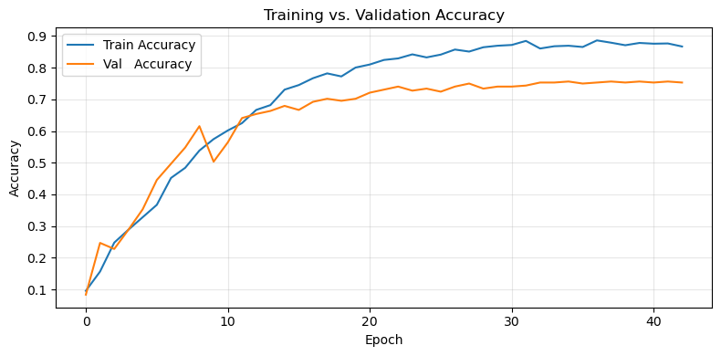

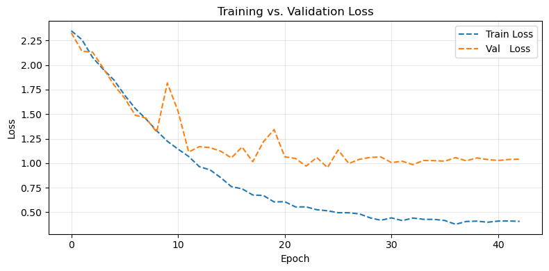

```python
import tensorflow as tf, numpy as np, matplotlib.pyplot as plt
from tensorflow.keras import layers, models, regularizers
from sklearn.metrics import confusion_matrix, classification_report
import pathlib, datetime, io, os

# -------- (2) fix the best HP -------------------------------------------------------
BEST = {
    "f0": 128, "f1": 256, "f2": 256, "k": 7,
    "dense": 128, "dense_dp": 0.3,
    "wd": 4.726311111933952e-05,
    "lr": 1e-4, "batch": 16, "use_plateau": True,
    "rot": 0.10, "zoom": 0.0, "flip": False,
}

# -------- (3) final --------------------------------------------------------
def build_final():
    aug = tf.keras.Sequential([layers.Rescaling(1/255.)], name="aug")
    if BEST["flip"]:  aug.add(layers.RandomFlip("horizontal"))
    if BEST["rot"] :  aug.add(layers.RandomRotation(BEST["rot"]))
    if BEST["zoom"]:  aug.add(layers.RandomZoom(BEST["zoom"]))

    l2 = regularizers.l2(BEST["wd"])
    model = models.Sequential([
        aug,
        layers.Conv2D(BEST["f0"], BEST["k"], activation="relu",
                      padding="same", kernel_regularizer=l2),
        layers.MaxPooling2D(),
        layers.Conv2D(BEST["f1"], BEST["k"], activation="relu",
                      padding="same", kernel_regularizer=l2),
        layers.MaxPooling2D(),
        layers.Conv2D(BEST["f2"], BEST["k"], activation="relu",
                      padding="same", kernel_regularizer=l2),
        layers.MaxPooling2D(),
        layers.Flatten(),
        layers.Dense(BEST["dense"], activation="relu", kernel_regularizer=l2),
        layers.Dropout(BEST["dense_dp"]),
        layers.Dense(num_classes, activation="softmax")
    ])
    model.compile(
        optimizer=tf.keras.optimizers.Adam(BEST["lr"]),
        loss="sparse_categorical_crossentropy",
        metrics=["accuracy"])
    return model

model = build_final()

# -------- (4) dir preparation ------------------------------------------------------------
stamp   = datetime.datetime.now().strftime("%Y%m%d-%H%M%S")
tb_dir  = pathlib.Path("tb_final", stamp)
art_dir = pathlib.Path("eval_artifacts");  art_dir.mkdir(parents=True, exist_ok=True)

# -------- (5) training + TensorBoard --------------------------------------------------
cbs = [
    tf.keras.callbacks.TensorBoard(log_dir=tb_dir, update_freq="epoch"),
    tf.keras.callbacks.EarlyStopping(
        monitor="val_accuracy", patience=10, min_delta=0.01, restore_best_weights=True)
]
if BEST["use_plateau"]:
    cbs.append(
        tf.keras.callbacks.ReduceLROnPlateau(
            monitor="val_loss", factor=0.5, patience=3)
    )

history = model.fit(
    train_ds,
    validation_data=val_ds,
    epochs=50,
    batch_size=BEST["batch"],
    callbacks=cbs
)

# -------- (6) confussion matrix -----------------------------------------------------
y_true = np.concatenate([y for _, y in val_ds], axis=0)
y_pred = model.predict(val_ds, verbose=0).argmax(axis=1)

cm = confusion_matrix(y_true, y_pred)
fig, ax = plt.subplots(figsize=(6,6))
im = ax.imshow(cm, cmap="Blues")
ax.set_xticks(range(num_classes), class_names, rotation=45, ha="right")
ax.set_yticks(range(num_classes), class_names)
for (i,j), v in np.ndenumerate(cm):
    ax.text(j, i, int(v), ha='center', va='center',
            color="white" if v > cm.max()*0.6 else "black", fontsize=7)
plt.colorbar(im, fraction=0.046)
ax.set_xlabel("Predicted"); ax.set_ylabel("True"); plt.tight_layout()
cm_png = art_dir / "confusion_matrix.png"; fig.savefig(cm_png, dpi=300); plt.close()

# TensorBoard -> Images
with tf.summary.create_file_writer(str(tb_dir)).as_default():
    png_bytes = tf.io.read_file(str(cm_png))
    img_tensor = tf.io.decode_png(png_bytes, channels=4)[tf.newaxis]
    tf.summary.image("confusion_matrix", img_tensor, step=0)

report = classification_report(y_true, y_pred, target_names=class_names, digits=3)
(art_dir / "classification_report.txt").write_text(report)
print(report)

# -------- (7) training prozess PNG --------------------------------------------------------
plt.figure(figsize=(6,4))
plt.plot(history.history["accuracy"],      label="train_acc")
plt.plot(history.history["val_accuracy"],  label="val_acc")
plt.plot(history.history["loss"],          label="train_loss", ls="--")
plt.plot(history.history["val_loss"],      label="val_loss",   ls="--")
plt.xlabel("Epoch"); plt.ylabel("Metric"); plt.legend(); plt.tight_layout()
curve_png = art_dir / "training_curves.png"; plt.savefig(curve_png, dpi=300); plt.close()

print(f"\ndone!\nTensorBoard logs : {tb_dir}\n"
      f"Confusion matrix : {cm_png}\n"
      f"Classification   : {art_dir/'classification_report.txt'}\n"
      f"Curves           : {curve_png}\n")
print("\nrun:  tensorboard serve --logdir tb_final --port 6006")

# -------- (8) In-Notebook Training Curve Visualization ---------------------------
import matplotlib.pyplot as plt

# Plot accuracy curves
plt.figure(figsize=(8, 4))
plt.plot(history.history["accuracy"],     label="Train Accuracy")
plt.plot(history.history["val_accuracy"], label="Val   Accuracy")
plt.title("Training vs. Validation Accuracy")
plt.xlabel("Epoch")
plt.ylabel("Accuracy")
plt.legend()
plt.grid(alpha=0.3)
plt.tight_layout()
plt.show()

# Plot loss curves
plt.figure(figsize=(8, 4))
plt.plot(history.history["loss"],     label="Train Loss", linestyle="--")
plt.plot(history.history["val_loss"], label="Val   Loss",   linestyle="--")
plt.title("Training vs. Validation Loss")
plt.xlabel("Epoch")
plt.ylabel("Loss")
plt.legend()
plt.grid(alpha=0.3)
plt.tight_layout()
plt.show()
```

# This cell is for visualization of everything with Tensorboard.

```python
! tensorboard serve --logdir tb_final --port 6006
```

# evaluation of model showing in the notebook

```
2025-07-14 20:07:17.328627: W tensorflow/core/framework/local_rendezvous.cc:404] Local rendezvous is aborting with status: OUT_OF_RANGE: End of sequence
```

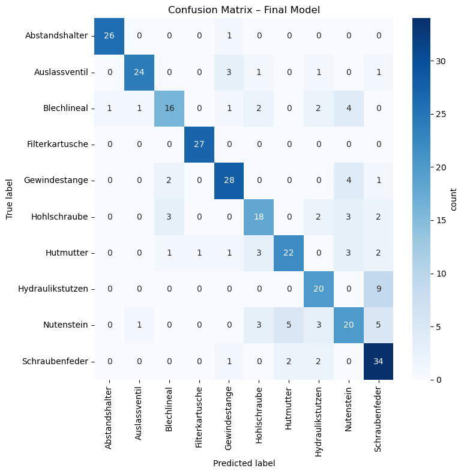

```
Classification Report – Final Model

                  precision    recall  f1-score   support

  Abstandshalter      0.963     0.963     0.963        27
   Auslassventil      0.923     0.800     0.857        30
     Blechlineal      0.727     0.593     0.653        27
 Filterkartusche      0.964     1.000     0.982        27
   Gewindestange      0.800     0.800     0.800        35
    Hohlschraube      0.667     0.643     0.655        28
       Hutmutter      0.759     0.667     0.710        33
Hydraulikstutzen      0.667     0.690     0.678        29
      Nutenstein      0.588     0.541     0.563        37
  Schraubenfeder      0.630     0.872     0.731        39

        accuracy                          0.753       312
       macro avg      0.769     0.757     0.759       312
    weighted avg      0.759     0.753     0.752       312
```

```python
# 1) Confusion Matrix & Classification Report

# gather ground truth and predictions
y_true = np.concatenate([y for _, y in val_ds], axis=0)
y_pred = model.predict(val_ds, verbose=0).argmax(axis=1)

# compute confusion matrix
cm = confusion_matrix(y_true, y_pred)

# plot heatmap
plt.figure(figsize=(8,8))
sns.heatmap(cm, annot=True, fmt="d", cmap="Blues",
            xticklabels=class_names, yticklabels=class_names,
            cbar_kws=dict(label="count"))
plt.xlabel("Predicted label")
plt.ylabel("True label")
plt.title("Confusion Matrix – Final Model")
plt.tight_layout()
plt.show()

# print classification report
print("Classification Report – Final Model\n")
print(classification_report(
    y_true, y_pred, target_names=class_names, digits=3, zero_division=0
))
```

These things are written above saperately in the code, here is a summary of the process.

## Bewertung der Optimierungsschritte (DE)

Die Optimierung erfolgte schrittweise, beginnend mit einem Basismodell und anschließend durch eine umfangreiche Hyperparameter-Suche:

1. **Basismodell:** Das ursprüngliche Modell (`3 × [Conv+Pool] + Flatten + Dense`) erzielte nach 40 Epochen eine Validierungsgenauigkeit (**val_acc**) von etwa **60,3 %** bei einem Verlust (**val_loss**) von **1,57**. Dieses Ergebnis dient als Referenzpunkt für die weitere Optimierung.
2. **Architektur- und Trainingsoptimierung:** Durch Bayesian-Optimierung der Architektur- und Trainingsparameter (Anzahl der Filter, Kernelgröße, Dropout-Rate, Gewicht-Regularisierung, Lernrate, Batch-Größe und Lernraten-Scheduler) wurde ein deutlicher Fortschritt erzielt. Die besten gefundenen Hyperparameter (`f0=128, f1=256, f2=256, Kernelgröße=7, Dense=128, Dropout=0,3, Gewicht-Regularisierung≈4,73e-5, Adam-Optimizer mit LR=1e-4 und Batchgröße=16`) führten zu einer signifikanten Steigerung der Validierungsgenauigkeit auf etwa **65,7 %** bei einem Verlust von **1,90**. Die größere Kernelgröße (7) und eine stärkere Modellkapazität trugen dabei entscheidend zur Verbesserung bei.
3. **Optimierung durch Datenaugmentation:** Zusätzlich wurde mittels gezielter Bayesian-Optimierung eine systematische Untersuchung der Datenaugmentation durchgeführt (Rotation, Zoom, horizontale Spiegelung). Die optimalen Einstellungen (Rotation: 10 %, Zoom: 0 %, Flip: False) führten zu einer weiteren signifikanten Steigerung der Validierungsgenauigkeit auf rund **79,2 %** und zu einem reduzierten Verlust von **1,05**. Besonders die moderate Rotation erwies sich hierbei als wirksam, um die Robustheit des Modells zu verbessern.
4. **Trainingstaktiken:** Der Einsatz von Early-Stopping mit Geduld von 10 Epochen sowie eines Plateau-LR-Schedulers (Reduzierung der Lernrate bei Stagnation) verbesserten zusätzlich die Stabilität und Konvergenz des Trainings deutlich, reduzierten das Overfitting-Risiko und gewährleisteten einen optimalen Trainingsabschluss.

### Fazit (Gesamtbewertung)

Insgesamt brachte die systematische und iterative Optimierung – bestehend aus Architektur- und Hyperparameter-Suche sowie der gezielten Datenaugmentation – eine substanzielle Steigerung der Modellleistung. Die Validierungsgenauigkeit erhöhte sich insgesamt um rund **18,9 Prozentpunkte** gegenüber dem ursprünglichen Basismodell. Die sorgfältige Kombination aus Modellstruktur, Trainingsmethoden und Datenaugmentation erwies sich somit als äußerst effektiv für die Optimierung.

below is english version (for myself).

## Assessment of the Optimization Steps (EN)

The optimization proceeded step-by-step, starting from a baseline model and followed by extensive hyperparameter tuning:

### Conclusion (Overall Assessment)

Overall, the systematic and iterative optimization—consisting of architectural and hyperparameter search combined with targeted data augmentation—yielded substantial improvements in model performance. The validation accuracy increased by approximately **18.9 percentage points** compared to the original baseline model. The careful combination of model architecture, training strategies, and data augmentation proved highly effective in optimizing performance.

I Think

For applications that require higher performance or stricter accuracy, further improvements are possible.

These could include using larger model architectures such as ResNet, applying more advanced data augmentation techniques like MixUp, or converting images to grayscale to reduce irrelevant color variations.